# HW_4_Jake_Nyiri

Jake Nyiri

11/18/2020

# BONANZA CREEK LTER

### Juvenile Snowshoe Hares

#### Jake Nyiri

**Introduction**

**Data and Methods**

Counts and measurements of juvenile snowshoes hares were collected from trapping regimes at three sites in the LTER over 12 years (Kielland, K., F.S. Chapin, R.W. Ruess, and Bonanza Creek LTER. 2017. Snowshoe hare physical data in Bonanza Creek Experimental Forest: 1999-Present ver 22. Environmental Data Initiative.). The locations consisted of a riparian near-stream area, lowlands dominated by balck spruce, and mature, upland boreal forest with a mix of alder, birch, and spruce. Hare weight, sex, foot length, and ear length were recorded. In this analysis, weights were compared across the three sites and summary statistics prepared for both sexes of hare. A two-sample t-test was used to explore differences between the average weights of male and female hares, with a Cohens’ *d* effect size determined. Relationships between hare weight and hind foot length were examined and a linear model created to try to describe the relationship. All analysis was conducted with R 3.6.2

**Hare Counts**  
We first explored general trends in the observed population over the temporal range of the data by visualizing the number of hares trapped each year.

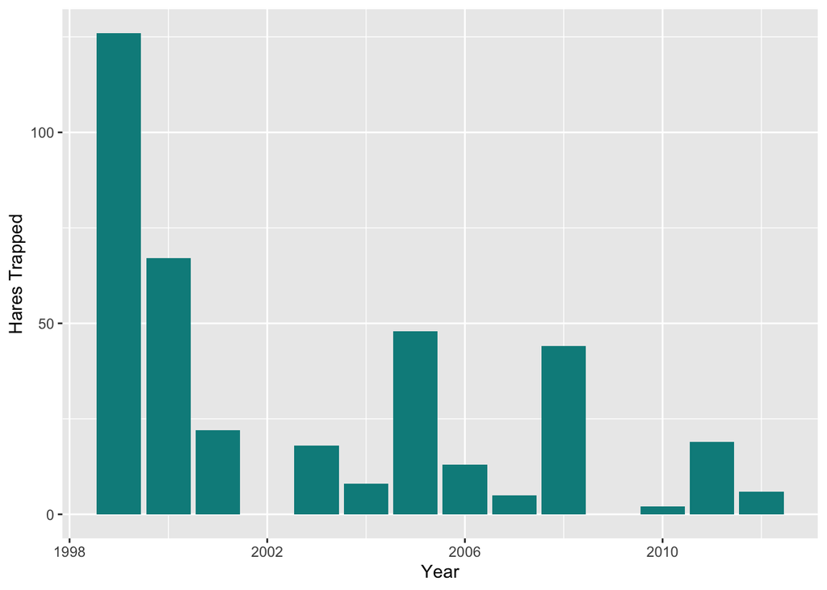

**Hare Weights Across Sample Locations**  
Next we analyzed the weights of the captured hares across both sex and grid location in the sample area.

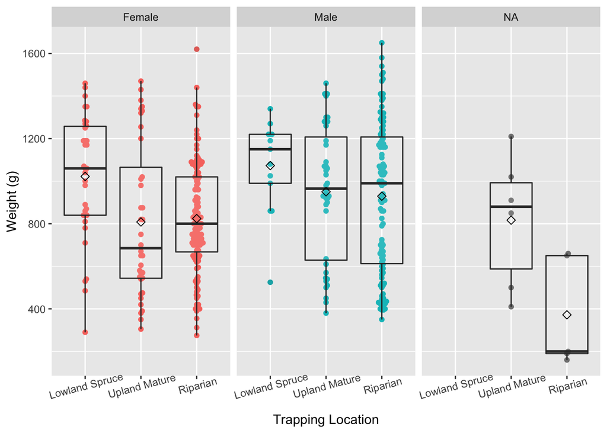

**Figure 2**  
Juvenile Snowshoe Hare Weights By Sex and Location. The colored dots represent individual hare measurements. The boxes show the limits of the middle 50% of each dataset, and the line and diamond in each box represent the median and mean, respectively.  
The data indicates that average female weights are similar in the upland and riparian areas (808g and 824g respectively) and somewhat higher in the lowland (1022g). The average male weight varied less by location (1073g for lowland, 950g for upland and 929g for riparian), however the range of male weights was much wider in the riparian area than the lowlands. For both sexes the largest number of captures occurred in the riparian area, and the least in the lowlands.

**Comparison Of Juvenile Hare Weights By Sex**  
Captured hares were grouped by sex and analyzed for any significant difference in their average weights utilizing a two-sample t-test.

Table 1: Hare Weights By Sex

| Sex | Mean Weight(g) | Standard Deviation | Number Trapped |
| --- | --- | --- | --- |
| Female | 855.4 | 292.3 | 197 |
| Male | 945.9 | 333.2 | 163 |

After checking for normality of the data using a QQ plot, we do not see a result for either sex which is as normalized as we would prefer, especially at the low end of the weights, but we still consider the data sample sufficiently normal to apply a two-sample t-test. Male hares had a mean weight of 945.9g $\pm$ 333.2g and females had a mean weight of 855.4g $\pm$ 292.3g. The difference in the means of the two samples was 90.5g, or a 10.05% difference, and although this was found to be significant (Welch’s t-test, t(325.02) = -2.71, p = 0.007, the effect size was not very large (Cohen’s *d* = -0.29).

**Juvenile Hare Foot Length and Weight Modeling**  
Finally we created a simple linear model to try to explore any potential relationship between hare weight and length of their rear feet.

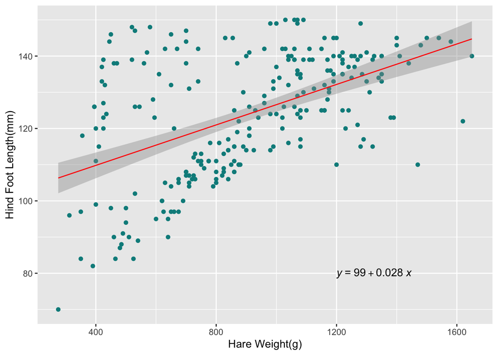

**Figure 3**  
Juvenile hare hind foot length as a function of weight. Each dot represents an individual hare, with males and females grouped together. The red line represents the regression line, with the regression equation displayed in the lower right.

**DATA CITATION** (Kielland, K., F.S. Chapin, R.W. Ruess, and Bonanza Creek LTER. 2017. Snowshoe hare physical data in Bonanza Creek Experimental Forest: 1999-Present ver 22. Environmental Data Initiative.)